# Diapositivas · Capítulo 4 — Patrones puntuales · Estadística Espacial

← Índice

Universidad El Bosque

Estadística Espacial

Clase magistral · 90 min

# Patrones puntuales

Ventana e intensidadCSRCuadrantesG · F · JK · L · gBordeEnvolventes

**Javier Mauricio Sierra**

Universidad El Bosque

Estadística Espacial

Capítulo 4 · Patrones puntuales

Cómo leer esta clase

La ventana forma parte del estimador

Tres regímenes y una referencia: CSR

Contar en cajas: el test de cuadrantes

Medir distancias en vez de contar cajas: G, F y J

Todas las escalas a la vez: K, L y g

¿Podemos creer la curva? Borde y envolventes

Cierre y práctica

Hoja de ruta

## Lo que vamos a construir hoy

Objetivo de la sesión

En un patrón puntual, «¿está agrupado?» no tiene respuesta hasta que se fijan y se declaran cuatro cosas: la ventana, la escala, la corrección de borde y la referencia contra la que se compara.

Ventana e intensidadCSRCuadrantesG · F · JK · L · gBordeEnvolventes

2 / 46

Universidad El Bosque

Estadística Espacial

Capítulo 4 · Patrones puntuales

Cómo leer esta clase

La ventana forma parte del estimador

Tres regímenes y una referencia: CSR

Contar en cajas: el test de cuadrantes

Medir distancias en vez de contar cajas: G, F y J

Todas las escalas a la vez: K, L y g

¿Podemos creer la curva? Borde y envolventes

Cierre y práctica

01

## Cómo leer esta clase

Cada cifra trae su fuente y cada afirmación, su etiqueta: dato, interpretación o criterio.

3 / 46

Cómo leer esta clase

## Cada cifra trae su fuente y cada afirmación, su etiqueta

### Dato

Una cifra calculada. Va con su fuente: el módulo del capítulo y el archivo del precálculo.

### Interpretación

La lectura que el capítulo hace del dato. Se puede discutir.

### Criterio

Una postura o recomendación del autor: qué hacer, no qué se midió.

Fuentes: `datos` es `cap4_datos.json` y `soluciones` es `cap4_soluciones.json`, generados con R (spatstat 3.5.1) en `precalculo/salidas/`. El cotejo de cada cifra está en `fuentes/registro_cifras_cap4.md`.

Capítulo 4 · Patrones puntualesEstadística Espacial · UnBosque4 / 46

Tesis del capítulo

## «¿Está agrupado?» no tiene respuesta hasta que fijamos ventana, escala, borde y referencia

Cuadrantes, G, F, K, g y envolventes son herramientas distintas, y todas obligan a fijar esas cuatro cosas y a declararlas.

Fuente: módulo 12 (texto del capítulo). Es una tesis del autor, no una cifra.

Capítulo 4 · Patrones puntualesEstadística Espacial · UnBosque5 / 46

Universidad El Bosque

Estadística Espacial

Capítulo 4 · Patrones puntuales

Cómo leer esta clase

La ventana forma parte del estimador

Tres regímenes y una referencia: CSR

Contar en cajas: el test de cuadrantes

Medir distancias en vez de contar cajas: G, F y J

Todas las escalas a la vez: K, L y g

¿Podemos creer la curva? Borde y envolventes

Cierre y práctica

02

## La ventana forma parte del estimador

Tenemos 2 209 sedes educativas de Bogotá y una pregunta sencilla: ¿cuántas hay por kilómetro cuadrado? La respuesta depende de dónde miremos.

Leer en el material: Qué es un proceso puntual

6 / 46

La ventana forma parte del estimador

## En un patrón puntual lo aleatorio es el dónde, y la ventana forma parte del estimador

- **Antes** el dato traía su sitio y variaba el valor. **Ahora se invierte**: el dato es la posición.
- El `ppp` tiene dos partes inseparables: las **coordenadas** y la **ventana de observación**.
- La ventana afirma que, en ese recinto y solo en él, se habría visto un punto de haberlo.

El ejemplo que nos acompaña: las sedes educativas de Bogotá

**Qué ilustra:** cómo cambia el resultado según la ventana. **De dónde sale:** 2 209 sedes georreferenciadas y el perímetro urbano (SED y SDP, vía Datos Abiertos Bogotá / IDECA, versión 12.25). **Por qué importa:** es el hilo colombiano de datos abiertos del curso; vuelve en el capítulo 5.

Fuente: módulo 1 · `datos › m1.sedes_total` · `FUENTES.md`, fuente 3.

Capítulo 4 · Patrones puntualesEstadística Espacial · UnBosque7 / 46

La ventana forma parte del estimador

## Misma ciudad, mismo dato, dos ventanas: 5.69321 sedes/km² contra 1.35200

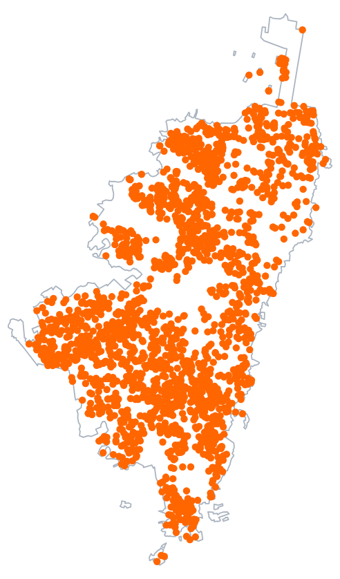

Sedes dentro del perímetro urbano

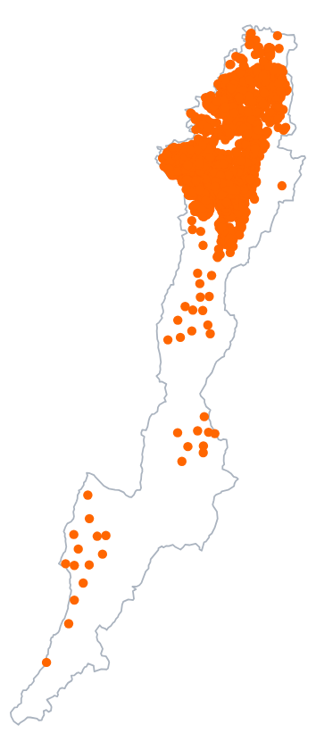

Las mismas sedes en el Distrito Capital completo

Dato

| Ventana | Sedes | Área (km²) | Sedes/km² |
| --- | --- | --- | --- |
| Perímetro urbano | 2 107 | 370.08982 | 5.69321 |
| Distrito Capital | 2 208 | 1633.14040 | 1.35200 |

Las dos intensidades se llevan un factor de **4.21097**.

Criterio

Publicar una intensidad sin decir su ventana la deja incompleta: ni verdadera ni falsa.

Fuente: módulo 1 · `datos › m1`.

Capítulo 4 · Patrones puntualesEstadística Espacial · UnBosque8 / 46

Pregunta para la clase

## Un informe dice «5,7 colegios por km²»: ¿qué le falta para estar completo?

1. Decir que la intensidad es una propiedad del dato, no del recinto.
2. Decir cuál es la ventana de observación usada.
3. Decir cuántos colegios hay en total en la ciudad.
4. Expresarla en hectáreas, la unidad de la escala urbana.

La 2: decir la ventana

Con el perímetro urbano salen 5.6932 sedes/km²; con el Distrito Capital entero, 1.3520: mismo dato, factor 4.21. Dar el total no arregla nada: el recuento apenas sube un 4.8 % entre las dos ventanas y la intensidad se cuadruplica.

Fuente: módulo 6, autoevaluación `cap4-trampas` · `datos › m1` y `m2`.

Capítulo 4 · Patrones puntualesEstadística Espacial · UnBosque9 / 46

La ventana forma parte del estimador

## Con λ = 5.6932 sedes/km² no basta: ese número solo sirve si λ es constante

$$\begin{aligned}\hat{\lambda} &= \frac{n}{|W|} = \frac{2\,107}{370.09\ \text{km}^2} \\ &= 5.6932\ \text{sedes/km}^2\end{aligned}$$

*n* es el número de sedes dentro de la ventana y *|W|*, su área.

Dato

Rejilla 10×10: **65** celdas «vivas» (con algo de área dentro de la ventana), 32.41538 sedes por celda de promedio; la más poblada tiene **96** y **9** están vacías.

Interpretación

Los conteos no son los de un Poisson homogéneo: con él la esperanza más alta de una celda es de **53.4** sedes, y una tiene 96. Qué falla, λ o la independencia, los conteos no lo dicen (módulo 5).

Fuente: módulo 2 · `datos › m2.urbana`.

Capítulo 4 · Patrones puntualesEstadística Espacial · UnBosque10 / 46

Universidad El Bosque

Estadística Espacial

Capítulo 4 · Patrones puntuales

Cómo leer esta clase

La ventana forma parte del estimador

Tres regímenes y una referencia: CSR

Contar en cajas: el test de cuadrantes

Medir distancias en vez de contar cajas: G, F y J

Todas las escalas a la vez: K, L y g

¿Podemos creer la curva? Borde y envolventes

Cierre y práctica

03

## Tres regímenes y una referencia: CSR

Antes de medir hay que saber qué se busca. Y «aleatorio» no es una impresión visual: es un modelo con nombre.

Leer en el material: Los tres regímenes

11 / 46

Tres regímenes y una referencia: CSR

## Los tres regímenes canónicos de la literatura se distinguen a simple vista

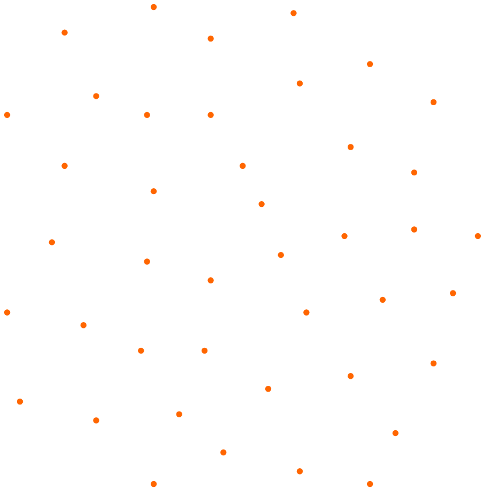

Células biológicas (Crick y Ripley), n = 42

**Regular**

Interpretación

Los puntos se estorban: cada célula ocupa un sitio y empuja a las demás.

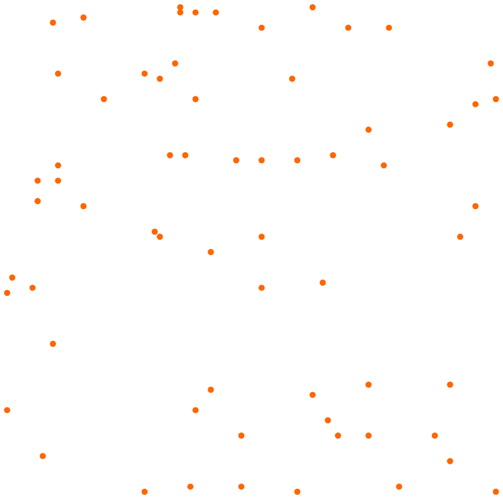

Pinos japoneses (Numata, 1961), n = 65

**Aleatorio**

Interpretación

Cada punto se coloca sin mirar dónde están los demás.

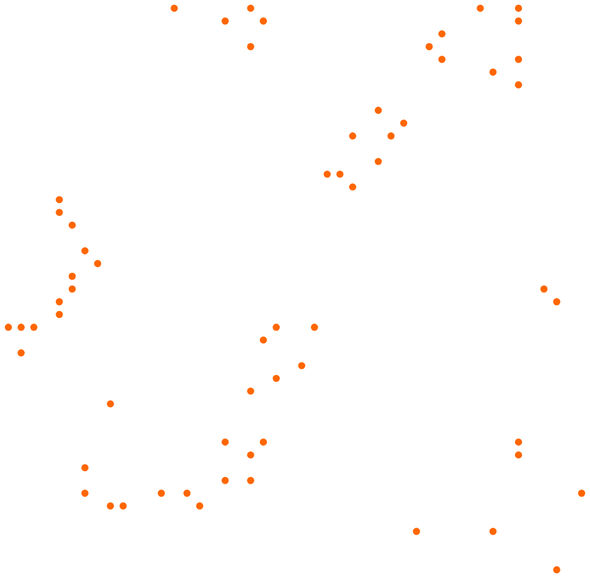

Plántulas de secuoya (Strauss, 1975; Ripley, 1977), n = 62

**Agregado**

Interpretación

Los puntos se atraen: las plántulas brotan cerca del árbol madre.

Fuente: módulo 3 · `datos › m3`.

Capítulo 4 · Patrones puntualesEstadística Espacial · UnBosque12 / 46

Tres regímenes y una referencia: CSR

## Clark-Evans: R < 1 indica agregación y R > 1, regularidad

**R** es la distancia media al vecino más próximo dividida por la que daría el azar, \(1/(2\sqrt{\lambda})\). **R < 1** agrega; **R ≈ 1**, aleatorio; **R > 1** regulariza.

Dato · R sin corregir el borde

| Patrón | Origen | n | R | Régimen |
| --- | --- | --- | --- | --- |
| Células | Crick y Ripley | 42 | **1.67168** | regular |
| Pinos suecos | Strand (1972) | 71 | **1.36008** | regular |
| Pinos japoneses | Numata (1961) | 65 | **1.06400** | aleatorio |
| Secuoyas | Strauss (1975) | 62 | **0.61865** | agregado |
| Sedes de Bogotá | SED, v. 12.25 | 2 107 | **0.82371** | agregado |

Interpretación

Las sedes quedan agregadas, pero no sabemos a qué escala ni cuánto: son los módulos 7 a 9.

Fuente: módulo 3 · `datos › m3`.

Capítulo 4 · Patrones puntualesEstadística Espacial · UnBosque13 / 46

Tres regímenes y una referencia: CSR

## CSR es un modelo con dos propiedades, y la primera es la que siempre se olvida

CSR: Poisson homogéneo

**(1) El número** de puntos en cualquier región A sigue una Poisson de media λ|A|.  
**(2) Las posiciones:** dado ese número, los puntos son uniformes e independientes.

La primera propiedad dice que dos realizaciones del mismo proceso **no tienen el mismo n**. Quien solo recuerda la segunda espera patrones con siempre los mismos puntos y se sorprende de lo que ve.

Fuente: módulo 4 (definición del capítulo).

Capítulo 4 · Patrones puntualesEstadística Espacial · UnBosque14 / 46

Tres regímenes y una referencia: CSR

## Dos mil realizaciones de CSR: n varía de 41 a 95, y media y varianza casi coinciden

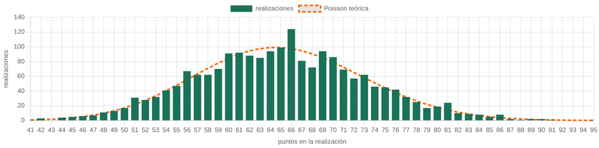

2 000 realizaciones simuladas de CSR (semilla 4026): conteos frente a la Poisson teórica

Dato

Con λ = 65 en el cuadrado unidad: media **64.979**, varianza **67.673**, recorrido de 41 a 95 puntos.

Interpretación

Media y varianza casi iguales a λ|W|: es la firma de Poisson (la binomial tiene la varianza por debajo; la binomial negativa, por encima).

Fuente: módulo 4 · `datos › m4`.

Capítulo 4 · Patrones puntualesEstadística Espacial · UnBosque15 / 46

Pregunta para la clase

## Una R de 0.95 en una realización de CSR: ¿qué se concluye?

1. Que la simulación falló, porque bajo CSR R debería dar 1.
2. Que la ventana es demasiado pequeña para que R sea informativo.
3. Que el patrón está agregado, porque R quedó por debajo de 1.
4. Que ese valor cae dentro de lo que el azar produce a menudo.

La 4: cae dentro de lo que el azar produce a menudo

En 2 000 realizaciones de azar puro, R recorrió de **0.83013** a **1.34170** (95 % central: 0.91306 a 1.20460) y **438** quedaron por debajo de 1. La media, 1.05843, no es 1: es sesgo de borde del estimador; corregido, los pinos japoneses bajan de 1.06400 a 1.00751.

Criterio

Una R sola, sin saber cuánto se mueve el azar, no dice nada.

Fuente: módulo 4, `cap4-quiz` · `datos › m4.R_csr`, `m3.japanesepines`.

Capítulo 4 · Patrones puntualesEstadística Espacial · UnBosque16 / 46

Universidad El Bosque

Estadística Espacial

Capítulo 4 · Patrones puntuales

Cómo leer esta clase

La ventana forma parte del estimador

Tres regímenes y una referencia: CSR

Contar en cajas: el test de cuadrantes

Medir distancias en vez de contar cajas: G, F y J

Todas las escalas a la vez: K, L y g

¿Podemos creer la curva? Borde y envolventes

Cierre y práctica

04

## Contar en cajas: el test de cuadrantes

Es el test más antiguo y el más fácil de explicar. También el que más se equivoca al decir qué contrasta.

Leer en el material: El test de cuadrantes

17 / 46

Contar en cajas: el test de cuadrantes

## El χ² de cuadrantes contrasta el Poisson homogéneo entero, no solo «λ constante»

$$\chi^2 = \sum_{j=1}^{m} \frac{(O_j - E_j)^2}{E_j} \qquad E_j = \lambda\,|A_j|$$

*O<sub>j</sub>* es lo observado en la celda *j*; *E<sub>j</sub>*, lo esperado si la nula fuera cierta: la intensidad por el área de la celda ya recortada contra la ventana.

Interpretación

La nula son las **dos** propiedades de CSR juntas. Un rechazo dice que algo de ese paquete falla, no cuál: un patrón con λ constante cuyos puntos se agrupan rechaza igual.

Dato

Sedes de Bogotá, rejilla 10×10: χ² = **456.12** con **64** grados de libertad y un p-valor del orden de 10<sup>-59.5</sup>. El test **rechaza**.

**12** de las 65 celdas vivas esperan menos de 5 puntos: el χ² se apoya en un supuesto que aquí no vale del todo.

Fuente: módulos 2 y 5 · `datos › m2.urbana` (`chi2`, `gl`, `p_log10`, `celdas_esperanza_baja`).

Capítulo 4 · Patrones puntualesEstadística Espacial · UnBosque18 / 46

Contar en cajas: el test de cuadrantes

## Dos patrones con el mismo χ² hasta el último decimal: 64.612903

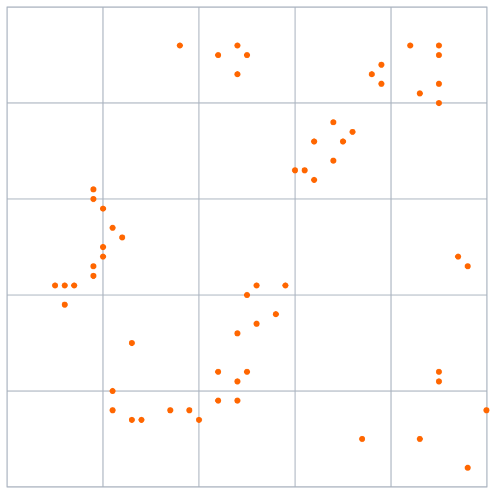

Secuoyas: el patrón original, con sus grumos

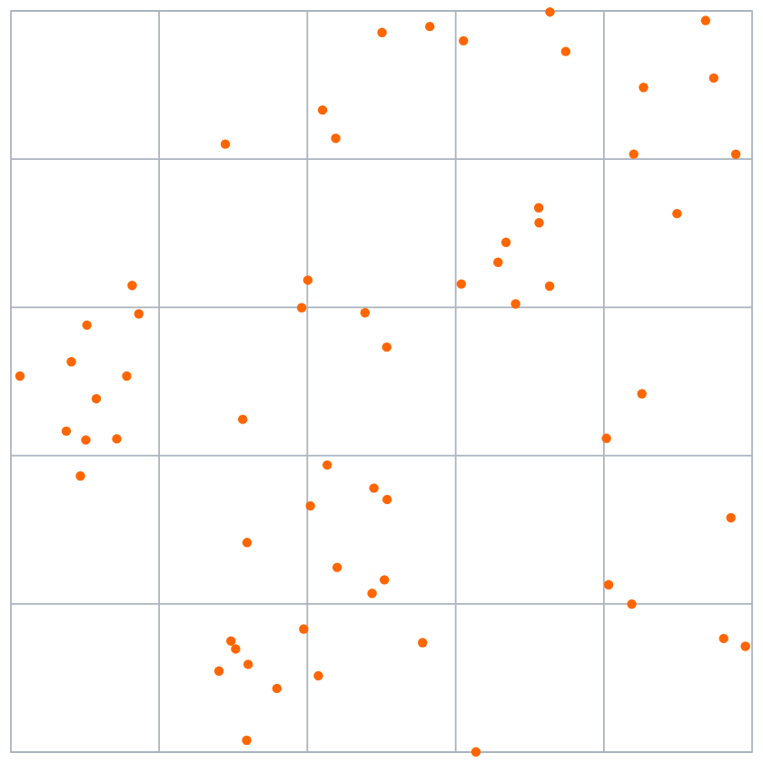

El mismo reparto por celda, sin grumos

Dato

|  | Original | Rebarajado |
| --- | --- | --- |
| χ² (24 gl) | 64.612903 | 64.612903 |
| Distancia media al vecino | 0.03928 | 0.05755 |
| R de Clark-Evans | 0.61865 | 0.90622 |

Interpretación

El χ² solo lee los conteos por celda, no cómo se colocan los puntos dentro. Unos grumos pequeños sí le llegan, porque desigualan los conteos; esta rebaraja, no.

Fuente: módulo 5 · `datos › m5`. Ejemplo construido: secuoyas rebarajadas dentro de cada celda 5×5.

Capítulo 4 · Patrones puntualesEstadística Espacial · UnBosque19 / 46

Contar en cajas: el test de cuadrantes

## El veredicto cambia con el tamaño de la celda cuando al test le falta potencia en alguna rejilla

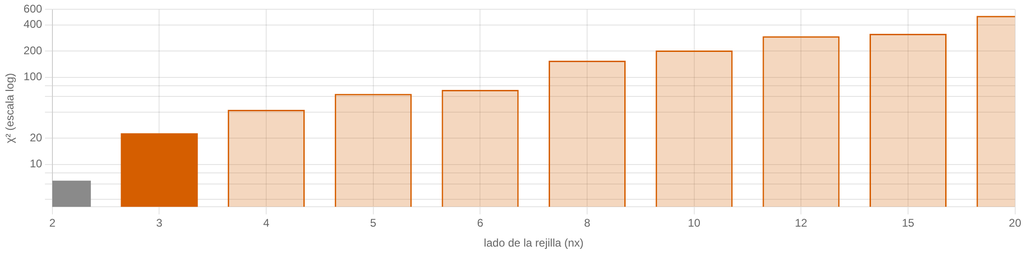

Secuoyas: χ² por lado de rejilla, de 2×2 a 20×20. Gris: no rechaza al 5 %. Naranja: rechaza. Pálido: alguna celda espera menos de 5 puntos

Dato

Rejillas que rechazan, de 10 tamaños: secuoyas **9**, pinos japoneses **0**, sedes de Bogotá **10**.

Fuente: módulo 6 · `datos › m6`; `soluciones › e3`.

Capítulo 4 · Patrones puntualesEstadística Espacial · UnBosque20 / 46

Contar en cajas: el test de cuadrantes

## Afinar la rejilla rompe el supuesto del χ²: con 400 celdas su p-valor ya no es de fiar

Dato · secuoyas, cuatro de las 10 rejillas

| Rejilla | χ² | p-valor |
| --- | --- | --- |
| 2×2 | 6.52 | 0.17806 |
| 5×5 | 64.61 | 0.00003 |
| 10×10 | 202.52 | 0.00000 |
| 20×20 | 505.74 | 0.00045 |

Solo las dos rejillas más gruesas respetan **al menos 5 puntos esperados por celda**, y la única que lo respeta *y* rechaza es la de 3×3: una de diez.

Interpretación

Con esperanzas tan pequeñas la aproximación falla: por simulación, el p de 20×20 sale **0.00326**, unas **7** veces el de arriba.

Fuente: módulo 6 · `datos › m6.redwood` y `m6.redwood_fina`.

Capítulo 4 · Patrones puntualesEstadística Espacial · UnBosque21 / 46

Pregunta para la clase

## Sobre las secuoyas el test rechaza con 5×5 y no con 2×2: ¿qué se hace con eso?

1. Quedarse con la rejilla fina, porque es la que mejor resuelve los grumos.
2. Declarar el tamaño de celda, que es parte del resultado y no del método.
3. Promediar los p-valores de los diez tamaños.
4. Fiarse de la rejilla gruesa, que es la que respeta la aproximación del χ².

La 2: declarar el tamaño de celda

La fina rompe el supuesto del χ²; promediar no tiene sentido porque los diez contrastes usan el mismo dato; y la gruesa respeta el supuesto pero le falta potencia: ve los conteos desiguales y aun así no rechaza. Es el efecto de escala del MAUP con otro nombre.

Criterio

Un test de cuadrantes sin su tamaño de celda en el pie está incompleto.

Fuente: módulo 6, autoevaluación `cap4-trampas`.

Capítulo 4 · Patrones puntualesEstadística Espacial · UnBosque22 / 46

Universidad El Bosque

Estadística Espacial

Capítulo 4 · Patrones puntuales

Cómo leer esta clase

La ventana forma parte del estimador

Tres regímenes y una referencia: CSR

Contar en cajas: el test de cuadrantes

Medir distancias en vez de contar cajas: G, F y J

Todas las escalas a la vez: K, L y g

¿Podemos creer la curva? Borde y envolventes

Cierre y práctica

05

## Medir distancias en vez de contar cajas: G, F y J

Las funciones de resumen resuelven el problema de la celda por la vía de no tener ninguna.

Leer en el material: Las funciones G y F

23 / 46

Medir distancias en vez de contar cajas: G, F y J

## G mira desde los puntos y F desde los huecos, y se confunden constantemente

### G(r) · vecino más próximo

Desde cada **punto del patrón**, hasta el *otro* punto más cercano. Ve lo cerca que tiene cada punto a su vecino.

$$\hat{G}(r) = \frac{1}{n}\sum_{i=1}^{n} \mathbf{1}\{d_i \leq r\}$$

### F(r) · espacio vacío

Desde **sitios cualesquiera** de la ventana, hasta el punto más cercano. Ve el tamaño de los huecos.

$$\hat{F}(r) = \frac{1}{m}\sum_{j=1}^{m} \mathbf{1}\{e_j \leq r\}$$

*d<sub>i</sub>* es la distancia del punto *i* a su vecino más próximo; *e<sub>j</sub>* es la del sitio *j* al punto más cercano.

Fuente: módulo 7 (definiciones del capítulo).

Capítulo 4 · Patrones puntualesEstadística Espacial · UnBosque24 / 46

Medir distancias en vez de contar cajas: G, F y J

## Bajo CSR G y F son la misma curva, y los regímenes las separan en direcciones opuestas

$$G_{\text{CSR}}(r) = F_{\text{CSR}}(r) = 1 - e^{-\lambda \pi r^2}$$

Dato

|  | G(r), vecino más próximo | F(r), espacio vacío |
| --- | --- | --- |
| Patrón agregado | Sube antes que la de CSR | Sube después que la de CSR |
| Patrón regular | Arranca después y sube más empinada | Sube antes que la de CSR |
| Bajo CSR | 1 − e<sup>−λπr²</sup> | La misma |

Interpretación

Un patrón agregado tiene vecinos cerca (G sube pronto) y deja huecos grandes (F sube tarde). Uno regular hace lo contrario.

Fuente: módulo 7 (teorema de Slivnyak, según el capítulo).

Capítulo 4 · Patrones puntualesEstadística Espacial · UnBosque25 / 46

Medir distancias en vez de contar cajas: G, F y J

## En los patrones de libro las medianas de G y F se separan de la de CSR como dice la teoría

Dato · mediana: la r a la que la curva llega a 1/2

| Patrón | G | F | CSR |
| --- | --- | --- | --- |
| Células (regular) | 0.13036 | 0.05959 | 0.07248 |
| Pinos japoneses (aleatorio) | 0.06403 | 0.05964 | 0.05826 |
| Secuoyas (agregado) | 0.02828 | 0.07769 | 0.05965 |

Interpretación

Regular: G llega tarde y F pronto. Agregado: al revés. Aleatorio: las tres casi coinciden.

Fuente: módulo 7 · `datos › m7`.

Capítulo 4 · Patrones puntualesEstadística Espacial · UnBosque26 / 46

Medir distancias en vez de contar cajas: G, F y J

## En Bogotá G y F dicen «agregado», pero no dicen por qué

Dato · sedes de Bogotá, ventana urbana

Mediana de G: **145.52** m. Mediana de F: **222.83** m. Bajo CSR las dos serían **196.86** m.

F usa 160 000 sitios y solo **62 762** caen dentro de la ventana: solo esos valen.

Interpretación

Exceso de vecinos cercanos y de huecos respecto de CSR. Una λ que cambia de zona en zona deja esa misma huella.

Criterio

Léelo como exceso de vecinos y de huecos, no como prueba de atracción. Un sitio fuera de la ventana no está vacío: está sin observar.

Fuente: módulo 7 · `datos › m7.bogota`.

Capítulo 4 · Patrones puntualesEstadística Espacial · UnBosque27 / 46

Pregunta para la clase

## La G sin corregir vale 0.037494 en r = 0: ¿cuántas sedes comparten coordenada con otra?

Sedes de Bogotá, ventana urbana (2 107 sedes). En los tres patrones de libro la G sin corregir vale 0 en r = 0; aquí no.

79 sedes

Es el **3.74941 %** de las sedes, y hay sitios con hasta **3** sedes. Son sedes distintas en un mismo edificio: la G tiene un átomo en r = 0.

Criterio

Un patrón con puntos duplicados no es un proceso puntual simple. No se colapsaron —cambiaría n y con él la λ publicada—: se declara.

Fuente: módulo 7 · `datos › m7.duplicados` y `m7.bogota`.

Capítulo 4 · Patrones puntualesEstadística Espacial · UnBosque28 / 46

Medir distancias en vez de contar cajas: G, F y J

## J junta G y F en una curva con referencia plana, pero J = 1 no certifica CSR

$$J(r) = \frac{1 - G(r)}{1 - F(r)} \qquad J = 1\ \text{bajo CSR} \quad J<1\ \text{agregado} \quad J>1\ \text{regular}$$

Dato

Pinos japoneses (aleatorios): J va de **0.29192** a **1.50037**. Bogotá: J queda por debajo de 1 en las **67** distancias.

Interpretación

Con esa regla, J llamaría regular a un patrón aleatorio en unas distancias y agregado en otras: ninguna función se lee sola.

Criterio

J = 1 no prueba CSR: Bedford y van den Berg (1997) construyeron, sobre la recta, procesos que no son de Poisson con J = 1.

Fuente: módulo 7 · `datos › m7`. J: van Lieshout y Baddeley (1996).

Capítulo 4 · Patrones puntualesEstadística Espacial · UnBosque29 / 46

Universidad El Bosque

Estadística Espacial

Capítulo 4 · Patrones puntuales

Cómo leer esta clase

La ventana forma parte del estimador

Tres regímenes y una referencia: CSR

Contar en cajas: el test de cuadrantes

Medir distancias en vez de contar cajas: G, F y J

Todas las escalas a la vez: K, L y g

¿Podemos creer la curva? Borde y envolventes

Cierre y práctica

06

## Todas las escalas a la vez: K, L y g

G y F miran una escala, la del vecino más próximo. K las mira todas, y por eso arrastra lo que encuentra.

Leer en el material: La función K de Ripley

30 / 46

Todas las escalas a la vez: K, L y g

## K cuenta vecinos en discos crecientes; bajo CSR vale πr², sea cual sea λ

$$K(r) = \frac{\mathbb{E}\left[\,N(r)\,\right]}{\lambda} \qquad K_{\text{CSR}}(r) = \frac{\lambda \pi r^2}{\lambda} = \pi r^2$$

*N(r)* es el número de *otros* puntos a distancia *r* o menos de un punto típico; al dividir por λ, K queda en unidades de **área**.

Interpretación

K(r) es el área del disco que, bajo CSR, tendría en promedio los vecinos que el patrón tiene de verdad. Si K(r) > πr², hay más vecinos de los que daría el azar.

Dato

La referencia no depende de la densidad: células (42 puntos), pinos japoneses (65) y secuoyas (62) comparten la misma curva teórica.

Fuente: módulo 8 · `datos › m3`, `m8`.

Capítulo 4 · Patrones puntualesEstadística Espacial · UnBosque31 / 46

Todas las escalas a la vez: K, L y g

## A 1 km la sede típica tiene 25.87 vecinas y el azar le daría 17.88

$$\hat{K}(r) = \frac{|W|}{n(n-1)} \sum_{i \neq j} w_{ij}\, \mathbf{1}\{d_{ij} \leq r\}$$

*w<sub>ij</sub>* es el peso de traslación de la pareja: corrige el borde.

Interpretación

A 1 km la sede típica tiene **1.45** veces las vecinas que daría el azar: el cociente entre K̂ y πr².

Dato · sedes de Bogotá, r = 1 km

| Pieza | Valor |
| --- | --- |
| Parejas ordenadas a ≤ 1 km | 50 368 |
| Suma con sus pesos | 54 511 |
| Vecinas por sede | 25.87 |
| Vecinas bajo CSR | 17.88 |
| K̂(1 km) | 4.5464 km² |
| πr² | 3.1416 km² |

Fuente: módulo 8 · `datos › m8.piezas`.

Capítulo 4 · Patrones puntualesEstadística Espacial · UnBosque32 / 46

Todas las escalas a la vez: K, L y g

## L − r pone CSR en el eje: su signo dice hacia dónde se aparta, no si importa

**L(r) = √(K(r)/π)** deshace el cuadrado: bajo CSR, \(L(r) - r = 0\). Se dibuja L − r contra r.

Dato · mayor desvío de L − r

| Patrón | Desvío |
| --- | --- |
| Células (regular) | −0.08463 |
| Pinos japoneses (aleatorio) | −0.01473 |
| Secuoyas (agregado) | +0.05581 |
| Sedes de Bogotá | +331.67 m, a 5105 m |

Interpretación

Los pinos, aleatorios, tienen signo negativo como las células regulares: el signo da la dirección, no la significancia. Sobre los pinos el test global da p = 0.30000: nada que rechazar.

Fuente: módulos 8 y 11 · `datos › m8`, `m11.test_global`.

Capítulo 4 · Patrones puntualesEstadística Espacial · UnBosque33 / 46

Pregunta para la clase

## K sigue por encima a 500 m aunque la agregación ocurre a 20 m: ¿por qué?

1. Porque la intensidad del patrón crece con la distancia medida.
2. Porque el efecto de borde infla K a las distancias grandes.
3. Porque la ventana no es un rectángulo simple.
4. Porque K es acumulativa y arrastra los vecinos ya contados.

La 4: K es acumulativa

Los vecinos de 20 m siguen contados dentro del disco de 500 m. Lo arregla g(r), que mira solo el anillo de radio r: \(g(r) = \frac{1}{2\pi r}\frac{dK(r)}{dr}\), y bajo CSR vale 1. Además, el borde va en sentido contrario: sin corregir, K se queda por debajo.

Fuente: módulo 12, `cap4-quiz`. Las distancias de 20 m y 500 m son las del enunciado de la pregunta, no una medición.

Capítulo 4 · Patrones puntualesEstadística Espacial · UnBosque34 / 46

Todas las escalas a la vez: K, L y g

## g mira solo el anillo: vuelve a 1 en r = 0.1450 mientras K sigue por encima

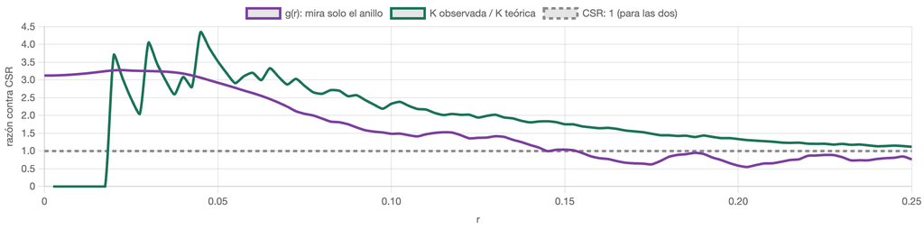

Secuoyas: g(r) y K observada sobre K teórica, las dos como razón contra CSR; la gris, el 1 de las dos

Dato

Secuoyas: g alcanza **3.27862** en r = **0.02250** y vuelve a 1 en r = **0.1450**; K sigue por encima de su teórica y no vuelve.

Interpretación

La distancia a la que g regresa es el tamaño de los grumos, y K no la sabe decir.

Fuente: módulo 9 · `datos › m9.redwood`.

Capítulo 4 · Patrones puntualesEstadística Espacial · UnBosque35 / 46

Todas las escalas a la vez: K, L y g

## K mira todas las escalas, pero acumula, supone λ constante y no mira lejos

Lo que hace bien

- Mira más allá del vecino más próximo: ninguna sede tiene el suyo a más de 2495 m; K sigue hasta 5868 m.
- Una curva para todas las escalas, sin celda ni ancho de banda que elegir.
- Su referencia, πr², no depende de λ.

Lo que no

- Es acumulativa: no dice a qué distancia está la estructura.
- Supone λ constante e isotropía: una λ que cambia deja la huella de la atracción.
- No mira lejos: `Kest()` llega a un cuarto del lado corto de la ventana (5868 m en Bogotá).
- No identifica el proceso: Baddeley y Silverman (1984) construyeron uno que no es de Poisson y tiene K = πr².

Fuente: módulo 8 · `datos › m3.bogota`, `m8.bogota`.

Capítulo 4 · Patrones puntualesEstadística Espacial · UnBosque36 / 46

Todas las escalas a la vez: K, L y g

## Cinco resúmenes miran el vecino o las cajas, y en Bogotá los cinco caen del lado agregado

Dato · sedes de Bogotá, ventana urbana

| Resumen | Qué cuenta | Resultado |
| --- | --- | --- |
| Clark-Evans R | Distancia al vecino, sobre la del azar | R = 0.82371 |
| χ² de cuadrantes | Conteos por celda frente a los del azar | rechaza en las 10 rejillas |
| G(r) | Puntos con vecino a r o menos | mediana 145.52 m (CSR: 196.86 m) |
| F(r) | Sitios con un punto a r o menos: los huecos | mediana 222.83 m |
| J(r) | (1 − G) / (1 − F) | por debajo de 1 en 67 distancias |

Interpretación

La agregación no mueve a todos hacia arriba: suben el χ² y G, que cuentan vecinos o desigualdad; bajan R, F y J, que miden distancias y huecos.

Fuente: módulos 3 a 7 · `datos › m3`, `m7`; `soluciones › e3`.

Capítulo 4 · Patrones puntualesEstadística Espacial · UnBosque37 / 46

Todas las escalas a la vez: K, L y g

## K, L − r y g también dicen «agregado»; ninguno dice por qué

Dato · sedes de Bogotá, ventana urbana

| Resumen | Qué cuenta | Resultado |
| --- | --- | --- |
| K(r) | Vecinos a r o menos, entre λ: el disco | 1.45 veces CSR a 1 km |
| L(r) − r | K en la escala de r | +331.67 m, a 5105 m |
| g(r) | Parejas por anillo | 1.01105 a 5868 m: no regresa a 1 |

Interpretación

Ninguno de los ocho dice **por qué** se aparta el patrón: una λ que cambia deja la misma huella que la atracción.

Criterio

Hasta el capítulo 5, «exceso de parejas», no «atracción»: tampoco dicen si el desvío supera al azar (módulo 11) ni cuánto pesa el borde (módulo 10).

Fuente: módulos 8 y 9 · `datos › m8`, `m9`.

Capítulo 4 · Patrones puntualesEstadística Espacial · UnBosque38 / 46

Universidad El Bosque

Estadística Espacial

Capítulo 4 · Patrones puntuales

Cómo leer esta clase

La ventana forma parte del estimador

Tres regímenes y una referencia: CSR

Contar en cajas: el test de cuadrantes

Medir distancias en vez de contar cajas: G, F y J

Todas las escalas a la vez: K, L y g

¿Podemos creer la curva? Borde y envolventes

Cierre y práctica

07

## ¿Podemos creer la curva? Borde y envolventes

Todo lo anterior tiene una grieta: un punto pegado al borde tiene vecinos fuera de la ventana, y nadie los ha observado.

Leer en el material: Efectos de borde

39 / 46

¿Podemos creer la curva? Borde y envolventes

## Ignorar el borde añade dirección: siempre hacia «más regular»

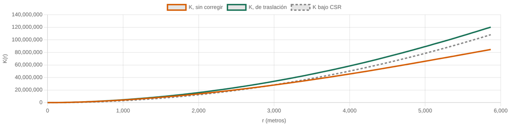

Sedes de Bogotá: K sin corregir, K de traslación y K bajo CSR

Dato

La K sin corregir queda hasta un **29.6 %** por debajo de la corregida; el máximo, en r = **5868** m. En el Mac del autor (R 4.4.1, 12 núcleos), la isotrópica tardó **555** veces más que la de traslación.

Interpretación

Faltan vecinos, nunca sobran: a r grande casi todos los discos tocan el borde.

Fuente: módulo 10 · `datos › m10`. Las envolventes usan la corrección de traslación, y se declara.

Capítulo 4 · Patrones puntualesEstadística Espacial · UnBosque40 / 46

¿Podemos creer la curva? Borde y envolventes

## Una banda al 95 % por punto no contrasta la curva: la mitad del azar puro se sale

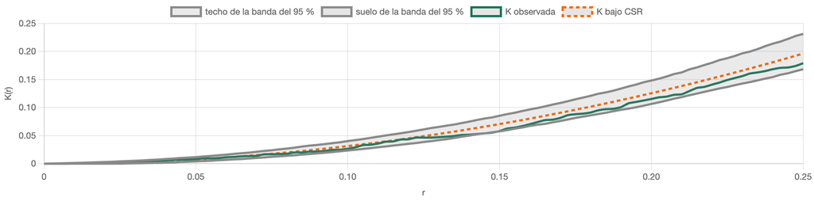

Pinos japoneses (aleatorios): banda del 95 % en cada r, de 999 simulaciones de CSR, y K observada

Dato

De 999 simulaciones de CSR puro, se salen de su banda en algún r: **52.2523 %** en las sedes, **52.1522 %** en las secuoyas y **51.0511 %** en los pinos. La observada de los pinos se sale cerca de r = **0.15**, tan poco que no se ve, y el test global no rechaza (p = **0.30000**).

Interpretación

La tasa la pone el procedimiento —513 distancias con una banda al 95 % en cada una—, no el dato.

Fuente: módulo 11 · `datos › m11`.

Capítulo 4 · Patrones puntualesEstadística Espacial · UnBosque41 / 46

¿Podemos creer la curva? Borde y envolventes

## El test global resume la curva en un número y obliga a declarar estadístico y rango

Dato

DCLF y MAD dan p = **0.00100** sobre Bogotá y **0.30000** y **0.31800** sobre los pinos. Con 999 simulaciones, el p mínimo posible es 1/(nsim + 1) = **0.00100**.

Interpretación

DCLF integra la separación al cuadrado; MAD toma la mayor. K crece como r², así que a r grande las desviaciones pesan más y ahogan la señal de las células, que está a r pequeño.

Dato · células, mismas 999 simulaciones

| DCLF sobre… | p |
| --- | --- |
| K, todo el rango de r | 0.08100 |
| K, r hasta el 20 % | 0.04900 |
| K, r hasta el 40 % | 0.00500 |
| L, todo el rango | 0.00100 |

Criterio

El estadístico y el rango de r los decide el analista: antes de mirar, y se declaran.

Fuente: módulo 11 · `datos › m11.test_global`; `soluciones › e4`.

Capítulo 4 · Patrones puntualesEstadística Espacial · UnBosque42 / 46

Pregunta para la clase

## De 39 a 999 simulaciones, sin tocar nada más: ¿qué le pasa a la banda por defecto?

1. Su ancho cae como uno partido por raíz de nsim, así que se reduce.
2. Se ensancha, porque su nivel puntual es 2/(nsim + 1) y ha cambiado.
3. Se estrecha, porque con más simulaciones hay más información sobre CSR.
4. No cambia: la banda queda determinada por el patrón y su ventana.

La 2: se ensancha

Con 39 simulaciones el nivel puntual es **0.05000**; con 999, **0.00200**: son contrastes distintos. En el barrido entero, desde 19 simulaciones, la banda se ensancha ×**1.84853**. Con el nivel fijo al 5 % sí se estrecha: ×**1.29989** entre 39 y 999.

Criterio

Elegir nsim no es elegir precisión: es elegir qué contrastes existen.

Fuente: módulo 11, `cap4-quiz` · `datos › m11.escala_resumen`.

Capítulo 4 · Patrones puntualesEstadística Espacial · UnBosque43 / 46

Universidad El Bosque

Estadística Espacial

Capítulo 4 · Patrones puntuales

Cómo leer esta clase

La ventana forma parte del estimador

Tres regímenes y una referencia: CSR

Contar en cajas: el test de cuadrantes

Medir distancias en vez de contar cajas: G, F y J

Todas las escalas a la vez: K, L y g

¿Podemos creer la curva? Borde y envolventes

Cierre y práctica

08

## Cierre y práctica

Leer en el material: Autoevaluación y ejercicios

44 / 46

Cierre y práctica

## Lo que se llevan hoy

- Ninguna cifra sin su ventana: n y λ cambian con el recinto
- El χ² solo cuenta cajas: el tamaño de la celda es parte del resultado
- G, F y J miran al vecino; K y L, todas las escalas pero acumulando; g, solo el anillo
- Ignorar el borde sesga siempre hacia «más regular»
- Una curva sin banda del azar no se lee; el test global obliga a declarar estadístico y rango

Javier Mauricio Sierra

Capítulo 4 · Patrones puntualesEstadística Espacial · UnBosque45 / 46

Cierre y práctica

## Cinco ejercicios, cinco decisiones que hay que defender

Práctica guiada del módulo 12

| Ejercicio | La decisión que hay que defender |
| --- | --- |
| 1 · La ventana que decides | ¿Qué ventana respalda «5,7 colegios por km²», y qué habría que añadir? |
| 2 · El χ² que no ve | ¿Qué cifra separa el patrón de los pinos suecos de su versión rebarajada, y cuál no? |
| 3 · El cuadrante que rechaza por el motivo equivocado | Urbana frente a Distrito Capital: ¿qué rechazo no habla de los colegios? |
| 4 · La envolvente dice una cosa y el test otra | ¿Cómo pasa el mismo patrón de no rechazar a rechazar? |
| 5 · El borde empuja siempre hacia el mismo lado | Al ignorar el borde, ¿el patrón parece más agregado o más regular? |

Fuente: módulo 12, ejercicios guiados · `soluciones › e1` a `e5`. Ejemplo del ejercicio 2: pinos suecos (Strand, 1972).

Capítulo 4 · Patrones puntualesEstadística Espacial · UnBosque46 / 46

### Atajos del teclado

[output not shown]

·

00:00

A continuación

Notas